# CostCurves R-Package

**Author:** Paulina Morillo

**e-mail:** paumoal@inf.upv.es

## Description

Tools for visualization and comparison of cost curves and the choice of threshold. Given predictions and class labels. ROC curve can be plotted and TPR (True positives rate), FPR (FP False positives rate) and AUCC (area under the curve costs) can also be computed.

Available in github: https://github.com/paumoal/CostCurves-R_package.git

## Installation

For linux download: “CostCurves_0.1.0.tar”

```r
#install.packages("../CostCurves_0.1.0.tar")
```

For windows download: “CostCurves_0.1.0”

```r
#install.packages("../CostCurves_0.1.0")
```

## Get Started

### Enable Library

```r
library(CostCurves)
```

### Load data

```r
data<-data("predictions")
classes<-predictions$classes
A<- predictions$A
B<- predictions$B
C<- predictions$B
```

### Examples

#### **Brier Curves (score driven treshold choice method)**

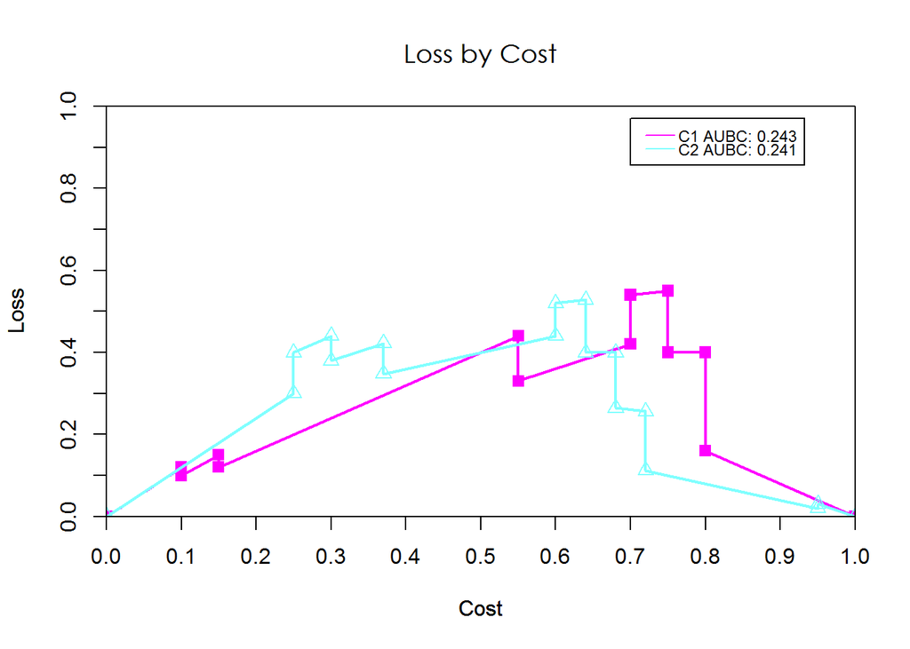

```r
#Loss by cost
R<-BrierCurves(list(A, B), list(classes),   uniquec = TRUE, pointsOFF=FALSE)
```

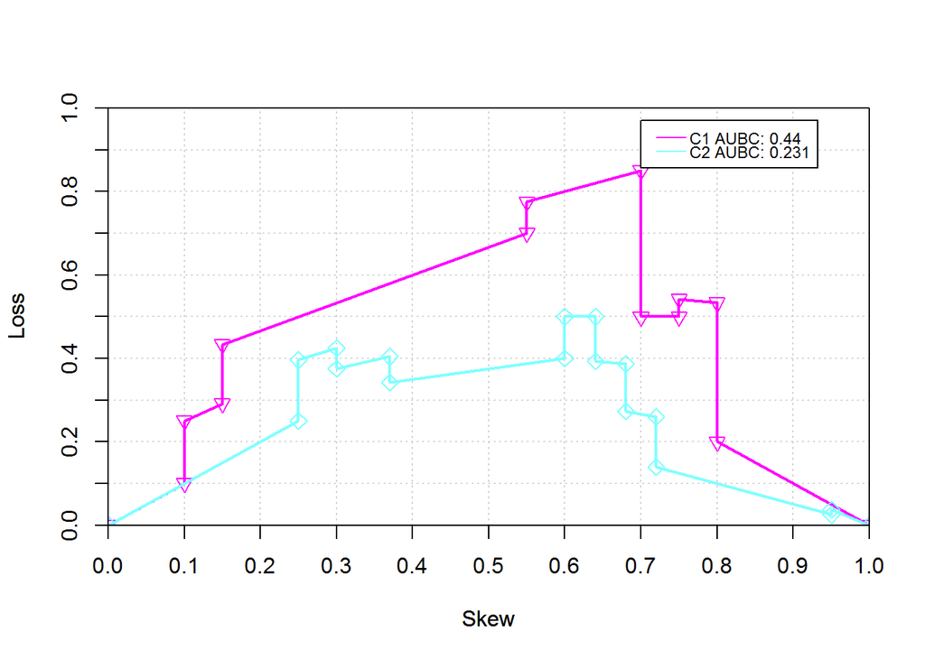

```r
#Loss by skew
R<-BrierCurves(list(A, B), list((1-classes), classes), loss2skew = TRUE, gridOFF = FALSE, pointsOFF=FALSE, main=NULL)
```